# Vehicular data trace

of the city of Belo Horizonte and surroundings, Brazil

P. Rettore

Computer Science Department, Federal University of Minas Gerais

January 22, 2018

[figure not shown]

[figure not shown]

We are making available the vehicular data acquired to develop research in Intelligent Transportation Systems (ITS) and Vehicular Ad-hoc Networks(VANETs). The following document describes the dataset and some characteristics. We also highlighted the works published using it.

## Introduction

Nowadays, modern vehicles have high technology embedded systems to improve their driving safety, performance and fuel consumption (Kilometer per Litre – KPL). Currently, a vehicle collects information from hundreds of sensors that are connected to the Engine Control Unit (ECU) through an internally wired sensor network and the data they output are accessible using the On-Board Diagnostic (OBD) interface.

The most recent interface is OBD-II, which was introduced to standardize the physical connector, its pinout, the signaling protocols and the format of the messages they deal with. The system is usually employed to monitor and regulate gas emissions and must be present in all cars produced since 1996 in Europe and United States. The OBD interface also helps aftermarket maintenance services when tracing the origin of mechanical problems since it stores engine fault codes that provide mechanics with information about problems and their sources. The collection process uses the OBD-II interface as the means of accessing the vehicle’s data, transferring them via the Bluetooth connection to a smartphone with the Android operating system, where the data is processed and registered through an app.

A case study was made based on sensor data from two vehicles shared by fourteen drivers. Figure 1 presents the setup of data collection process. An important aspect of this process concerns the types of trips recorded by both vehicles: all four drivers sharing Vehicle 2 were asked to drive through two different routes, while the ten drivers of Vehicle 1 used it for several ends in their daily routines. **For the driver’s privacy, all data available were anonymized, then the start and end of each trip was deleted, reducing the amounts of data.**

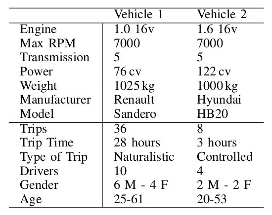

## Data Characteristics

Dataset features

```
##  [1] "Car_Id"                    "Person_Id"
##  [3] "Trip"                      "GPS_Time"
##  [5] "Device_Time"               "GPS_Long"
##  [7] "GPS_Lat"                   "GPS_Speed_Ms"
##  [9] "GPS_HDOP"                  "GPS_Bearing"
## [11] "Gx"                        "Gy"
## [13] "Gz"                        "G_Calibrated"
## [15] "OBD_KPL_Average"           "OBD_Trip_KPL_Average"
## [17] "OBD_Intake_Air_Temp_C"     "Device_Barometer_M"
## [19] "GPS_Altitude_M"            "OBD_Engine_Load"
## [21] "OBD_Fuel_Level"            "GPS_Accuracy_M"
## [23] "OBD_Speed_Km"              "GPS_Speed_Km"
## [25] "Device_Trip_Dist_Km"       "OBD_Engine_Coolant_Temp_C"
## [27] "OBD_Engine_RPM"            "OBD_Adapter_Voltage"
## [29] "OBD_KPL_Instant"           "OBD_Fuel_Flow_CCmin"
## [31] "Device_Fuel_Remaining"     "OBD_Ambient_Air_Temp_C"
## [33] "OBD_CO2_gkm_Average"       "OBD_CO2_gkm_Instant"
## [35] "Device_Cost_Km_Inst"       "Device_Cost_Km_Trip"
## [37] "OBD_Air_Pedal"             "Context"
## [39] "Acceleration_kmhs"         "Reaction_Time"
## [41] "Air_Drag_Force"            "Speed_RPM_Relation"
## [43] "KPL_Instant"
```

**Vehicle 1**

Time of data acquired, number of drivers and total of trips:

```
## Time Collected (hour):  23.6375
```

```
## Number of Drivers:  10
```

```
## The total of Trips:  36
```

Space coverage:

[figure not shown]

**Vehicle 2**

Time of data acquired, number of drivers and total of trips:

```
## Time Collected (hour):  1.860833
```

```
## Number of Drivers:  4
```

```
## The total of Trips:  8
```

Space coverage:

[figure not shown]

## Download Datasets

We encourage the community to explore the data acquired which is now available. **Please cite Rettore et al. (2018), if this data will guide your investigations.**

*Vehicular Traces [download](https://drive.google.com/file/d/13PZusOqXnNgV4YrNYRXXobhcIbh-Eusd/view?usp=sharing)*

## Publications

P. H. Rettore, André, et al. (2016)[link](http://ieeexplore.ieee.org/abstract/document/7795542/): Guided us to better understand vehicular data after processing it. This work lead us to eliminate and treat data problems such as outliers, conflict, incompleteness, ambiguity, correlation, and disparateness.

Rettore et al. (2017)[link](http://ieeexplore.ieee.org/document/8024676/): We developed a virtual gear sensor for manual transmission cars, which allows relating each individual gear with the fuel consumption. They proposed a methodology to recommend the best gears according to current speed and torque. Using such methodology, they were able to reduce the fuel consumption by about 29% and the CO2 emissions in about 21%.

Campolina et al. (2017)[link](http://ieeexplore.ieee.org/document/8271956/): Designing a virtual sensor is usually a difficult process due to the complexity of the different processing stages it comprises. This work presents a study on the process of creating and prototyping vehicular virtual sensors, describing development stages and presenting examples of virtual sensors created with a framework developed to facilitate the design process.

Cunha et al. (2017)[link](http://homepages.dcc.ufmg.br/~fdcunha/MinicursoTextoV2.pdf): In this mini-course, the objective is to discuss ITS, presenting an overview of the area, its challenges, and opportunities. In this way, this mini-course will introduce the main concepts involved in the ITS architecture, its implementation and integration with other computer networks, and how to evaluate its performance. We will also show the main applications in the literature that cooperate for the existence of ITS. In the end, we will discuss the challenges and opportunities found in the areas of interest of the SBRC symposium, among which we highlight: data collection and fusion, characterization, prediction, security and privacy.

Rettore et al. (2018): This work explores the driver identification as an extra authentication factor to local services and vehicular networks. Then, a virtual sensor was developed to determine the driver identity, with precision above 98%, using embedded sensor data. This sensor was also used to identify driver suspects. Besides, based on the suspect identification, we discussed the impacts of these drivers in the data dissemination in a vehicular network.

## Thanks

The volunteers who allowed the advance of these investigations, and the support of Capes/CNPq a Brazilian Federal Agency for Support and Evaluation of Graduate Education.

## Bibliography

Campolina, A. B., P. H. L. Rettore, M. D. V. Machado, and A. A. F. Loureiro. 2017. “On the Design of Vehicular Virtual Sensors.” In *2017 13th International Conference on Distributed Computing in Sensor Systems (Dcoss)*, 134–41. Ottawa, Canada. doi:10.1109/DCOSS.2017.21.

Cunha, Felipe Domingos da, Guilherme Maia, Clayson Celes, Daniel Guidoni, Fernanda de Souza, Heitor Ramos, and Leandro Villas. 2017. “Sistemas de Transporte Inteligentes: Conceitos, Aplicações e Desafios.” In *SBRC 2017 - Minicursos ()*. http://homepages.dcc.ufmg.br/~fdcunha/MinicursoTextoV2.pdf.

Rettore, P. H. L., A. B. Campolina, L. A. Villas, and A. A. F. Loureiro. 2017. “A Method of Eco-Driving Based on Intra-Vehicular Sensor Data.” In *2017 Ieee Symposium on Computers and Communications (Iscc)*, 1122–7. Heraklion, Greece: IEEE. doi:10.1109/ISCC.2017.8024676.

Rettore, Paulo Henrique, Bruno Pereira Santos André, Campolina, Leandro Aparecido Villas, and Antonio A.F. Loureiro. 2016. “Towards Intra-Vehicular Sensor Data Fusion.” In *Advanced Perception, Machine Learning and Data Sets (Amd’16) as Part of the 2016 Ieee 19th International Conference on Intelligent Transportation Systems (Itsc 2016)*. Rio de Janeiro.

Rettore, Paulo Henrique, André Campolina, Artur Luis de Souza, Guilherme Maia, Leandro Aparecido Villas, and Antonio A.F. Loureiro. 2018. “Driver Authentication in VANETs Based on Intra-Vehicular Sensor Data.” In *2018 Ieee Symposium on Computers and Communications (Iscc) (Iscc 2018)*. Natal, Brazil.

Rettore, Paulo Henrique, André Campolina, Leandro Aparecido Villas, and Antonio A.F. Loureiro. 2016. “Identifying Relationships in Vehicular Sensor Data: A Case Study and Characterization.” In *6th Acm International Symposium on Design and Analysis of Intelligent Vehicular Networks and Applications - 2016 (Divanet 2016)*. Malta.